# Eksploracja_danych

## Konstrukcja modelu prawdopodobieństwa wystąpienia szkody oraz średniej wartości szkody na potrzeby oszacowania ryzyka ubezpieczeniowego

**Autorzy:**  
Piotr Sulewski  
Dominik Mielczarek  
Łukasz Naklicki

Celem niniejszej pracy jest konstrukcja modeli służących ocenie ryzyka ubezpieczeniowego w ubezpieczeniu komunikacyjnym. Analizowane dane nie pozwalają na określenie rodzaju ubezpieczenia, co utrudnia analizę, jednakże założono, że dane dotyczą zdarzeń ubezpieczeniowych związanych z mniej lub bardziej poważnymi kolizjami drogowymi. Zbiór wykorzystany do analizy i modelowania pochodzi ze strony Kaggle: https://www.kaggle.com/datasets/xiaomengsun/car-insurance-claim-data.

Podział prac:

- przygotowanie i eksploracja danych: Piotr Sulewski, Łukasz Naklicki
- model prawdopodobieństwa wystąpienia szkody: Dominik Mielczarek
- model średniej wartości szkody: Piotr Sulewski

### Przygotowanie i eksploracja danych

Proces realizacji wyznaczonego celu rozpoczęto od przygotowania i eksploracji danych.

```python
import pandas as pd
import numpy as np
import seaborn as sns
import matplotlib.pyplot as plt
from matplotlib.ticker import PercentFormatter
from dateutil import relativedelta
import warnings
from sklearn.impute import KNNImputer
import missingno as msno
warnings.filterwarnings("ignore")
```

```python
df = pd.read_csv("car_insurance_claim.csv")
df.head()
```

|  | ID | KIDSDRIV | BIRTH | AGE | HOMEKIDS | YOJ | INCOME | PARENT1 | HOME_VAL | MSTATUS | ... | CAR_TYPE | RED_CAR | OLDCLAIM | CLM_FREQ | REVOKED | MVR_PTS | CLM_AMT | CAR_AGE | CLAIM_FLAG | URBANICITY |
| --- | --- | --- | --- | --- | --- | --- | --- | --- | --- | --- | --- | --- | --- | --- | --- | --- | --- | --- | --- | --- | --- |
| 0 | 63581743 | 0 | 16MAR39 | 60.0 | 0 | 11.0 | $67,349 | No | $0 | z_No | ... | Minivan | yes | $4,461 | 2 | No | 3 | $0 | 18.0 | 0 | Highly Urban/ Urban |
| 1 | 132761049 | 0 | 21JAN56 | 43.0 | 0 | 11.0 | $91,449 | No | $257,252 | z_No | ... | Minivan | yes | $0 | 0 | No | 0 | $0 | 1.0 | 0 | Highly Urban/ Urban |
| 2 | 921317019 | 0 | 18NOV51 | 48.0 | 0 | 11.0 | $52,881 | No | $0 | z_No | ... | Van | yes | $0 | 0 | No | 2 | $0 | 10.0 | 0 | Highly Urban/ Urban |
| 3 | 727598473 | 0 | 05MAR64 | 35.0 | 1 | 10.0 | $16,039 | No | $124,191 | Yes | ... | z_SUV | no | $38,690 | 2 | No | 3 | $0 | 10.0 | 0 | Highly Urban/ Urban |
| 4 | 450221861 | 0 | 05JUN48 | 51.0 | 0 | 14.0 | NaN | No | $306,251 | Yes | ... | Minivan | yes | $0 | 0 | No | 0 | $0 | 6.0 | 0 | Highly Urban/ Urban |

5 rows × 27 columns

### Opis zmiennych

```python
df.info()
```

```
<class 'pandas.core.frame.DataFrame'>
RangeIndex: 10302 entries, 0 to 10301
Data columns (total 27 columns):
 #   Column      Non-Null Count  Dtype
---  ------      --------------  -----
 0   ID          10302 non-null  int64
 1   KIDSDRIV    10302 non-null  int64
 2   BIRTH       10302 non-null  object
 3   AGE         10295 non-null  float64
 4   HOMEKIDS    10302 non-null  int64
 5   YOJ         9754 non-null   float64
 6   INCOME      9732 non-null   object
 7   PARENT1     10302 non-null  object
 8   HOME_VAL    9727 non-null   object
 9   MSTATUS     10302 non-null  object
```

[output cut: 19 more lines]

### Zawartość ramki danych

'ID' - Identyfikator

'KIDSDRIV' - Liczba dzieci klienta mogących prowadzić samochód

'BIRTH' - Data urodzenia

'AGE' - Wiek

'HOMEKIDS' - Liczba dzieci w domu klienta

'YOJ' - Liczba przepracowanych lat w miejscu pracy

'INCOME' - Dochód

'PARENT1' - Czy klient jest samotnym rodzicem

'HOME_VAL' - Wartość domu

'MSTATUS' - Stan cywilny

'GENDER' - Płeć

'EDUCATION' - Poziom wykształcenia

'OCCUPATION' - Zawód

'TRAVTIME' - Czas dojazdu do pracy w minutach

'CAR_USE' - Charakter użytkowania pojazdu (prywatny/komercyjny)

'BLUEBOOK' - Wartość pojazdu

'TIF' - Liczba lat jako klient (Time in Force)

'CAR_TYPE' - Typ pojazdu

'RED_CAR' - Czy samochód ma kolor czerwony

'OLDCLAIM' - Łączna wartość szkód w ostatnich 5 latach

'CLM_FREQ' - Liczba szkód w ostatnich 5 latach

'REVOKED' - Odebranie prawa jazdy w ostatnich 7 latach

'MVR_PTS' - Punkty karne (Motor Vehicle Record Points)

'CLM_AMT' - Wartość szkody

'CAR_AGE' - Wiek samochodu

'CLAIM_FLAG' - Wystąpienie szkody

'URBANICITY' - Stopień urbanizacji miejsca zamieszkania

### Weryfikacja unikalnych wartości i poprawności typów danych

```python
for i in df.columns:
    print(i, df[i].dtype)
    print(df.loc[:,i].unique())
```

```
ID int64
[ 63581743 132761049 921317019 ...  67790126 849208064 680381960]
KIDSDRIV int64
[0 1 2 3 4]
BIRTH object
['16MAR39' '21JAN56' '18NOV51' ... '13AUG54' '18JUN51' '27FEB47']
AGE float64
[60. 43. 48. 35. 51. 50. 34. 54. 40. 44. 37. 53. 55. 45. 39. 59. 42. 31.
 28. 47. 46. 33. 32. 49. 36. 52. 41. 56. 38. 63. 62. 30. 29. 58. 64. 66.
 26. 61. 80. 57. nan 25. 27. 20. 21. 19. 72. 69. 24. 67. 22. 23. 65. 70.
 17. 16. 81. 73. 71. 68. 18. 76.]
HOMEKIDS int64
[0 1 2 3 4 5]
YOJ float64
[11. 10. 14. nan 12.  7.  5.  0. 13.  9. 17.  8. 15. 16.  6. 18. 23.  4.
  3.  2. 19.  1.]
INCOME object
['$67,349' '$91,449' '$52,881' ... '$164,669' '$107,204' '$53,235']
PARENT1 object
['No' 'Yes']
HOME_VAL object
['$0' '$257,252' '$124,191' ... '$332,591' '$170,611' '$197,017']
MSTATUS object
['z_No' 'Yes']
GENDER object
['M' 'z_F']
EDUCATION object
['PhD' 'z_High School' 'Bachelors' '<High School' 'Masters']
OCCUPATION object
['Professional' 'z_Blue Collar' 'Manager' 'Clerical' 'Doctor' 'Lawyer' nan
 'Home Maker' 'Student']
TRAVTIME int64
[ 14  22  26   5  32  36  46  33  21  30  44  34  48  15  25  64  74  43
  45  42  27  29  52   8   7  16  37  12  38  65  18  47  10  40  62  35
  24  20  50  13  31  28  11   9  57  49  61  41  23  59  17  63  53  68
  54  60  39  69  55  73  51  58  81  19   6  83  56  75  84  70  67  72
  79  76  78  66  88  71  90  86  87 113  80  98  77  93  82 124  85 142
  99  95 105  92 134  89 103  97  91 101]
CAR_USE object
['Private' 'Commercial']
```

[output cut: 10 more lines]

```
CLM_FREQ int64
[2 0 1 3 5 4]
REVOKED object
['No' 'Yes']
MVR_PTS int64
[ 3  0  2 10  1  4  5 13  8  6  7  9 11 12]
CLM_AMT object
['$0' '$2,946' '$6,477' ... '$3,106' '$3,135' '$1,815']
CAR_AGE float64
[18.  1. 10.  6. 17.  7. 11.  9.  4.  5. 13. 16. 20. 14. 12. 15. nan  8.
  3. 21. 19. 23.  0. 22.  2. 26. 27. 24. 25. -3. 28.]
CLAIM_FLAG int64
[0 1]
URBANICITY object
['Highly Urban/ Urban' 'z_Highly Rural/ Rural']
```

Zidentyfikowano zmienne z nieprawidłowymi typami danych lub wartościami, które należy poprawić. Zmienna 'BIRTH' zapisana jest w formacie 'DDMMMRR' (np. '21MAR67') i traktowana jako tekst - należy dokonać konwersji na typ daty (datetime). Zmienne INCOME, HOME_VAL, BLUEBOOK, OLDCLAIM, CLM_AMT zawierają wartości liczbowe poprzedzone znakiem '$' z separatorem tysięcy ',' - oba znaki należy usunąć i dokonać konwersji na typ liczbowy (float/int). W danych występuje 10 zmiennych jakościowych traktowanych jako tekst a ponadto część wartości zawiera prefiks 'z_', który należy usunąć. Ww. zmienne powinny zostać przekonwertowane na typ kategorii (category).

### Oczyszczenie zmiennych i zmiana typów danych

**Usunięcie znaków '$' i ',' w zmiennych ilosciowych**

```python
# Zamiana znaków '$' i ',' na '' i konwersja typu na float
for i in df.columns:
    n = 0
    for j in list(df[i].values):
        if '$' in str(j):
            n += 1
            print(i)
            if n >= 1:
                df[i] = df[i].str.replace('$', '')
                df[i] = df[i].str.replace(',', '').astype(np.float32)
                break
```

```
INCOME
HOME_VAL
BLUEBOOK
OLDCLAIM
CLM_AMT
```

**Konwersja BIRTHDATE na typ daty**

```python
# Sprawdzenie czy wszystkie wartości w kolumnie 'BIRTH' mają dokładnie 7 znaków
df['BIRTH'].apply(lambda row: len(row)).agg(['min', 'max'])
```

```
min    7
max    7
Name: BIRTH, dtype: int64
```

```python
# Sprawdzenie czy wartości mogą pochodzić z XXI wieku
df['BIRTH'].apply(lambda row: row[-2:]).agg(['min', 'max'])
```

```
min    18
max    87
Name: BIRTH, dtype: object
```

Daty urodzenia obejmują lata 1918-1987

```python
# Modyfikacja roku urodzenia na pełny rok w celu łatwiejszej konwersji
df['BIRTH'] = df['BIRTH'].apply(lambda row: row[:-2] + '19' +  row[-2:])
df['BIRTH'].head()
```

```
0    16MAR1939
1    21JAN1956
2    18NOV1951
3    05MAR1964
4    05JUN1948
Name: BIRTH, dtype: object
```

```python
df['BIRTH'] = pd.to_datetime(df['BIRTH'], format='%d%b%Y')
```

**Usunięcie przedrostka 'z_'**

```python
# Wartości przed zmianą
for i in ['MSTATUS', 'GENDER', 'EDUCATION', 'OCCUPATION', 'CAR_TYPE', 'URBANICITY']:
    print(df.loc[:,i].unique())
```

```
['z_No' 'Yes']
['M' 'z_F']
['PhD' 'z_High School' 'Bachelors' '<High School' 'Masters']
['Professional' 'z_Blue Collar' 'Manager' 'Clerical' 'Doctor' 'Lawyer' nan
 'Home Maker' 'Student']
['Minivan' 'Van' 'z_SUV' 'Sports Car' 'Panel Truck' 'Pickup']
['Highly Urban/ Urban' 'z_Highly Rural/ Rural']
```

```python
# Usunięcie przedrostka 'z_'
for i in ['MSTATUS', 'GENDER', 'EDUCATION', 'OCCUPATION', 'CAR_TYPE', 'URBANICITY']:
    df.loc[:,i] = df.loc[:,i].apply(lambda row: row.replace('z_', '') if type(row) == str else row)
```

```python
# Wartości po zmianie
for i in ['MSTATUS', 'GENDER', 'EDUCATION', 'OCCUPATION', 'CAR_TYPE', 'URBANICITY']:
    print(df.loc[:,i].unique())
```

```
['No' 'Yes']
['M' 'F']
['PhD' 'High School' 'Bachelors' '<High School' 'Masters']
['Professional' 'Blue Collar' 'Manager' 'Clerical' 'Doctor' 'Lawyer' nan
 'Home Maker' 'Student']
['Minivan' 'Van' 'SUV' 'Sports Car' 'Panel Truck' 'Pickup']
['Highly Urban/ Urban' 'Highly Rural/ Rural']
```

**Weryfikacja pozostałych kategorii**

```python
for i in ['PARENT1', 'CAR_USE', 'RED_CAR', 'REVOKED']:
    print(df.loc[:,i].unique())
```

```
['No' 'Yes']
['Private' 'Commercial']
['yes' 'no']
['No' 'Yes']
```

```python
df['RED_CAR'] = df['RED_CAR'].replace(['no', 'yes'], ['No', 'Yes'])
```

**Konwersja zmiennych typu tekstowego na typ kategorii oraz zmiennych 0-1 na bool**

```python
df['PARENT1'][df['PARENT1'] == 'Yes'] = True
df['PARENT1'][df['PARENT1'] == 'No'] = False
df['PARENT1'] = df['PARENT1'].astype('bool')

df['MSTATUS'][df['MSTATUS'] == 'Yes'] = True
df['MSTATUS'][df['MSTATUS'] == 'No'] = False
df['MSTATUS'] = df['MSTATUS'].astype('bool')

df['RED_CAR'][df['RED_CAR'] == 'Yes'] = True
df['RED_CAR'][df['RED_CAR'] == 'No'] = False
df['RED_CAR'] = df['RED_CAR'].astype('bool')

df['REVOKED'][df['REVOKED'] == 'Yes'] = True
df['REVOKED'][df['REVOKED'] == 'No'] = False
df['REVOKED'] = df['REVOKED'].astype('bool')

df['CLAIM_FLAG'] = df['CLAIM_FLAG'].astype('bool')
```

```python
for i in df.columns:
    if df[i].dtype == 'object':
        df[i] = df[i].astype('category')
```

```python
df.info()
```

```
<class 'pandas.core.frame.DataFrame'>
RangeIndex: 10302 entries, 0 to 10301
Data columns (total 27 columns):
 #   Column      Non-Null Count  Dtype
---  ------      --------------  -----
 0   ID          10302 non-null  int64
 1   KIDSDRIV    10302 non-null  int64
 2   BIRTH       10302 non-null  datetime64[ns]
 3   AGE         10295 non-null  float64
 4   HOMEKIDS    10302 non-null  int64
 5   YOJ         9754 non-null   float64
 6   INCOME      9732 non-null   float32
 7   PARENT1     10302 non-null  bool
 8   HOME_VAL    9727 non-null   float32
 9   MSTATUS     10302 non-null  bool
```

[output cut: 19 more lines]

Po wykonaniu powyższych operacji zmienne mają poprawne typy danych:

- 11 zmiennych jakościowych (w tym 5 zmiennych 0-1)
- 15 zmiennych ilościowych
- 1 zmienna opisująca datę.

### Walidacja dat i zmiennych ilościowych w zbiorze

**Walidacja zakresu**

```python
df.iloc[:,1:].agg(['min', 'max'])
```

|  | KIDSDRIV | BIRTH | AGE | HOMEKIDS | YOJ | INCOME | PARENT1 | HOME_VAL | MSTATUS | TRAVTIME | BLUEBOOK | TIF | RED_CAR | OLDCLAIM | CLM_FREQ | REVOKED | MVR_PTS | CLM_AMT | CAR_AGE | CLAIM_FLAG |
| --- | --- | --- | --- | --- | --- | --- | --- | --- | --- | --- | --- | --- | --- | --- | --- | --- | --- | --- | --- | --- |
| min | 0 | 1918-07-04 | 16.0 | 0 | 0.0 | 0.0 | False | 0.0 | False | 5 | 1500.0 | 1 | False | 0.0 | 0 | False | 0 | 0.0 | -3.0 | False |
| max | 4 | 1987-12-03 | 81.0 | 5 | 23.0 | 367030.0 | True | 885282.0 | True | 142 | 69740.0 | 25 | True | 57037.0 | 5 | True | 13 | 123247.0 | 28.0 | True |

Zakresy wartości zmiennych nie budzą zastrzeżeń za wyjątkiem zmiennej 'CAR_AGE', w której występuje jedna wartość ujemna:

```python
len(df[df['CAR_AGE'] < 0])
```

```
1
```

```python
df[df['CAR_AGE'] < 0].squeeze()
```

```
ID                      676425834
KIDSDRIV                        0
BIRTH         1952-06-02 00:00:00
AGE                          47.0
HOMEKIDS                        0
YOJ                          12.0
INCOME                    48696.0
PARENT1                     False
HOME_VAL                 212014.0
MSTATUS                     False
GENDER                          F
EDUCATION               Bachelors
OCCUPATION           Professional
TRAVTIME                       46
CAR_USE                   Private
BLUEBOOK                  15390.0
TIF                             4
CAR_TYPE                   Pickup
RED_CAR                     False
OLDCLAIM                  33521.0
CLM_FREQ                        3
REVOKED                      True
MVR_PTS                         1
CLM_AMT                    1469.0
CAR_AGE                      -3.0
CLAIM_FLAG                   True
URBANICITY    Highly Urban/ Urban
Name: 8771, dtype: object
```

Prawdopodobną przyczyną błędu może być przypadkowe dopisanie znaku '-' przed wartością 3. Niepoprawną wartość należałoby usunąć, a następnie dokonać imputacji na podstawie posiadanych informacji o pozostałych zmiennych i obserwacjach lub po prostu zmienić ją na 3. Przed zastąpieniem wartości liczbą 3 zweryfikowano statystyki dotyczące wartości samochodu i dochodu 12 klientów posiadających 3-letnie pickupy:

```python
# BLUEBOOK: 15390, INCOME: 48696
df[(df['CAR_TYPE'] == 'Pickup') & (df['CAR_AGE'] == 3)][['BLUEBOOK', 'INCOME']].agg(['median', 'max', 'min', 'count'])
```

|  | BLUEBOOK | INCOME |
| --- | --- | --- |
| median | 9575.0 | 34522.0 |
| max | 28870.0 | 85731.0 |
| min | 4600.0 | 5409.0 |
| count | 12.0 | 11.0 |

Wartość samochodu klienta z niepoprawnym wiekiem pojazdu mieści się w zakresie 4600-28870 i przewyższa medianę. Biorąc pod uwagę fakt, że również dochód klienta jest wyższy od dochodu przeciętnego właściciela analogicznego pojazdu można uznać, że analizowany klient rzeczywiście posiada 3-letni samochód będący po prostu lepszym modelem niż samochód przeciętnego klienta ze względu na wyższe dochody.

```python
df.loc[8771, 'CAR_AGE'] = 3
```

**Weryfikacja czy wszystkie dane dotyczą tego samego roku**

```python
dates_check = (df[~df['AGE'].isna()]['BIRTH'] + df[~df['AGE'].isna()]['AGE'].apply(lambda row: relativedelta.relativedelta(years=row))).apply(lambda row: row.year)
dates_check.agg(['min', 'max'])
```

```
min    1998
max    1999
dtype: int64
```

Na podstawie analizy dat urodzenia i wieku klientów stwierdzono, że dane dotyczą lat 1998 i 1999. Prawdopodobne wydaje się, że wiek klienta określony jest na dzień zawarcia polisy, natomiast dane mogą dotyczyć szkód zgłoszonych w roku 1999. W zdecydowanej większośi bowiem uzyskany rok to 1999, zaś liczba obserwacji wskazujących na rok 1998 jest zbyt duża, aby można było uznać ją za błędną:

```python
dates_check.value_counts()
```

```
1999    9050
1998    1245
dtype: int64
```

**Weryfikacja występowania braków wieku i możliwości uzupełnienia ich wykorzystując datę urodzenia**

```python
df[df['AGE'].isna()]
```

|  | ID | KIDSDRIV | BIRTH | AGE | HOMEKIDS | YOJ | INCOME | PARENT1 | HOME_VAL | MSTATUS | ... | CAR_TYPE | RED_CAR | OLDCLAIM | CLM_FREQ | REVOKED | MVR_PTS | CLM_AMT | CAR_AGE | CLAIM_FLAG | URBANICITY |
| --- | --- | --- | --- | --- | --- | --- | --- | --- | --- | --- | --- | --- | --- | --- | --- | --- | --- | --- | --- | --- | --- |
| 295 | 242777133 | 0 | 1986-02-18 | NaN | 2 | 8.0 | 2954.0 | True | 0.0 | False | ... | Sports Car | True | 10099.0 | 2 | False | 4 | 6142.0 | 5.0 | True | Highly Urban/ Urban |
| 1317 | 55084702 | 0 | 1983-11-21 | NaN | 3 | 0.0 | 0.0 | True | 0.0 | False | ... | Minivan | True | 0.0 | 0 | False | 7 | 3092.0 | 8.0 | True | Highly Urban/ Urban |
| 1651 | 194301482 | 0 | 1984-10-18 | NaN | 2 | 0.0 | 0.0 | True | 0.0 | False | ... | SUV | True | 0.0 | 0 | False | 0 | 3444.0 | 6.0 | True | Highly Urban/ Urban |
| 3749 | 919557945 | 0 | 1986-02-17 | NaN | 2 | 0.0 | NaN | True | 0.0 | False | ... | Sports Car | True | 25235.0 | 1 | True | 0 | 2541.0 | 13.0 | True | Highly Urban/ Urban |
| 4365 | 968439150 | 0 | 1984-02-15 | NaN | 3 | 12.0 | 16227.0 | False | NaN | True | ... | Van | True | 0.0 | 0 | False | 6 | 5640.0 | 1.0 | True | Highly Urban/ Urban |
| 4554 | 285745137 | 0 | 1985-08-17 | NaN | 0 | 9.0 | 14484.0 | False | 0.0 | False | ... | Sports Car | True | 4518.0 | 1 | False | 1 | 4798.0 | 1.0 | True | Highly Urban/ Urban |
| 5227 | 945868698 | 0 | 1987-12-03 | NaN | 0 | 0.0 | 0.0 | False | NaN | True | ... | SUV | True | 4656.0 | 4 | False | 3 | 0.0 | 1.0 | False | Highly Rural/ Rural |

7 rows × 27 columns

Wszystkie obserwacje, które nie posiadają wartości opisującej wiek dotyczą osób urodzonych w latach 1983-1987, a zatem mających mniej niż 16 lat w roku, którego dotyczą dane. Należy zauważyć, że minimalny wiek klienta w posiadanych danych to właśnie 16 lat. Co ciekawe w przypadku 6 z 7 analizowanych klientów odnotowano szkodę. 5 z 7 klientów ma 2 lub 3 dzieci, jednak prawdopodonie na tyle młodych, że nie posiadają one jeszcze prawa jazdy ('KIDSDRIV' = 0). Wydaje się, że w większości przypadków rzeczywiście obserwacje dotyczą młodych klientów, jednak z pewnością nie takich, którzy mogliby mieć mniej niż 16 lat. Zmienną 'BIRTHDATE' można więc w ww. przypadkach uznać za błędną. Tym samym biorąc pod uwagę, że w pozostałych przypadkach wiek jest uzupełniony, zmienna nie wnosi żadnej dodatkowej wartości i można usunąć ją ze zbioru.

```python
del df['BIRTH']
```

**Weryfikacja poprawności zmiennej YOJ (Years on Job)**

```python
# Wyliczenie wieku klienta w momencie rozpoczęcia pracy
yoj_check = (df['AGE'] - df['YOJ']).value_counts().sort_index()
yoj_check[:20]
```

```
4.0       1
5.0       2
6.0       1
8.0       2
9.0       7
10.0      5
11.0     11
12.0     23
13.0     25
14.0     44
15.0     40
16.0     53
17.0     82
18.0     98
19.0    117
20.0    122
dtype: int64
```

```python
yoj_check.loc[0:13].sum()
```

```
77
```

```python
display(df[(df['AGE'] - df['YOJ']) <= 13][['INCOME', 'HOME_VAL', 'BLUEBOOK', 'YOJ']].agg(['count', 'mean', 'median']))
display(df[(df['AGE'] - df['YOJ']) > 13][['INCOME', 'HOME_VAL', 'BLUEBOOK', 'YOJ']].agg(['count', 'mean', 'median']))
display(df[(df['AGE'] - df['YOJ']) <= 13]['EDUCATION'].value_counts(normalize=True))
display(df[(df['AGE'] - df['YOJ']) > 13]['EDUCATION'].value_counts(normalize=True))
```

|  | INCOME | HOME_VAL | BLUEBOOK | YOJ |
| --- | --- | --- | --- | --- |
| count | 76.000000 | 74.000000 | 77.000000 | 77.000000 |
| mean | 29240.486328 | 89123.460938 | 11047.791992 | 12.493506 |
| median | 21488.000000 | 84216.500000 | 9430.000000 | 12.000000 |

|  | INCOME | HOME_VAL | BLUEBOOK | YOJ |
| --- | --- | --- | --- | --- |
| count | 9137.000000 | 9131.000 | 9670.000000 | 9670.000000 |
| mean | 62012.292969 | 155185.625 | 15666.333008 | 10.462565 |
| median | 54067.000000 | 161587.000 | 14390.000000 | 11.000000 |

```
High School     0.428571
Bachelors       0.285714
<High School    0.233766
Masters         0.051948
PhD             0.000000
Name: EDUCATION, dtype: float64
```

```
High School     0.288211
Bachelors       0.272389
Masters         0.201965
<High School    0.145502
PhD             0.091934
Name: EDUCATION, dtype: float64
```

Zidentyfikowano przypadki, które budzą wątpliwości co do merytorycznej poprawności danych dotyczących wieku i liczby przepracowanych lat. W 77 z nich klient musiałby rozpocząć pracę w wieku co najwyżej 13 lat. Analizując powyższe przypadki i porównując je z pozostałymi obserwacjami można stwierdzić wyraźne różnice w zamożności między obiema grupami pomimo podobnej liczby przepracowanych lat. Są to także osoby, które przeciętnie charakteryzują się niższym wykształceniem w stosunku do pozostałych klientów, co może sugerować wczesne rozpoczęcie pracy związane np. z trudną sytuacją materialną. Nie można zatem z całą pewnością stwierdzić błędów w danych, tym bardziej, że przypadki rozpoczęcia pracy w wieku poniżej 10 lat, a więc szczególnie podejrzane, występują tylko 13 razy. Należy jednak mieć na uwadze, że dane mogą zawierać błędy.

### Wstępna analiza danych

**Podstawowe statystyki opisowe zmiennych ilościowych**

```python
report = pd.DataFrame(df.iloc[:,1:].describe()).round(2)
report
```

|  | KIDSDRIV | AGE | HOMEKIDS | YOJ | INCOME | HOME_VAL | TRAVTIME | BLUEBOOK | TIF | OLDCLAIM | CLM_FREQ | MVR_PTS | CLM_AMT | CAR_AGE |
| --- | --- | --- | --- | --- | --- | --- | --- | --- | --- | --- | --- | --- | --- | --- |
| count | 10302.00 | 10295.00 | 10302.00 | 9754.00 | 9732.00 | 9727.00 | 10302.00 | 10302.00 | 10302.00 | 10302.00 | 10302.00 | 10302.00 | 10302.00 | 9663.00 |
| mean | 0.17 | 44.84 | 0.72 | 10.47 | 61572.14 | 154522.83 | 33.42 | 15659.95 | 5.33 | 4033.98 | 0.80 | 1.71 | 1511.27 | 8.30 |
| std | 0.51 | 8.61 | 1.12 | 4.11 | 47457.46 | 129186.62 | 15.87 | 8428.76 | 4.11 | 8733.08 | 1.15 | 2.16 | 4725.11 | 5.71 |
| min | 0.00 | 16.00 | 0.00 | 0.00 | 0.00 | 0.00 | 5.00 | 1500.00 | 1.00 | 0.00 | 0.00 | 0.00 | 0.00 | 0.00 |
| 25% | 0.00 | 39.00 | 0.00 | 9.00 | 27584.00 | 0.00 | 22.00 | 9200.00 | 1.00 | 0.00 | 0.00 | 0.00 | 0.00 | 1.00 |
| 50% | 0.00 | 45.00 | 0.00 | 11.00 | 53529.00 | 160661.00 | 33.00 | 14400.00 | 4.00 | 0.00 | 0.00 | 1.00 | 0.00 | 8.00 |
| 75% | 0.00 | 51.00 | 1.00 | 13.00 | 86166.00 | 238256.00 | 44.00 | 20890.00 | 7.00 | 4647.50 | 2.00 | 3.00 | 1144.75 | 12.00 |
| max | 4.00 | 81.00 | 5.00 | 23.00 | 367030.00 | 885282.00 | 142.00 | 69740.00 | 25.00 | 57037.00 | 5.00 | 13.00 | 123247.00 | 28.00 |

Powyżej przedstawiono podstawowe statystyki opisowe zmiennych ilościowych.

**Rozkłady zmiennych ilościowych**

```python
plt.style.use('ggplot')
```

```python
numeric_cols = [c for c in df.columns[1:] if (str(df[c].dtype) not in ['category', 'bool'])]
len(numeric_cols)
```

```
14
```

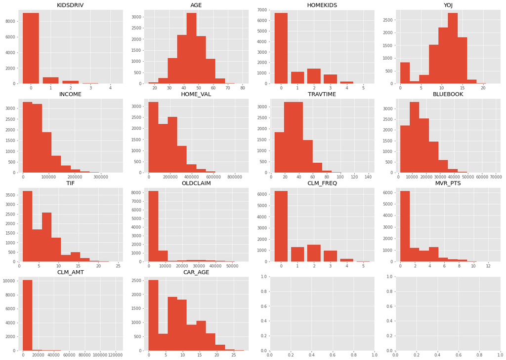

```python
# Wyświetlenie rozkładów zmiennych ilościowych
fig, axs = plt.subplots(4, 4, figsize=(22, 16))

numeric_cols_gen = (i for i in numeric_cols)
try:
    for i in range(len(axs)):
        for j in range(len(axs[i])):
            col = next(numeric_cols_gen)
            col_val_counts = df[col].value_counts()

            if len(col_val_counts) > 10:
                axs[i][j].hist(df[col])
                axs[i][j].set_title(col)
            else:
                axs[i][j].bar(col_val_counts.index, height=col_val_counts.values)
                axs[i][j].set_title(col)
except StopIteration:
    pass
plt.show()
```

Rozkłady wszystkich zmiennych za wyjątkiem zmiennych AGE oraz YOJ charakteryzują się widoczną asymetrią prawostronną.

**Zależności pomiędzy zmiennymi ilościowymi**

[figure not shown]

```python
numeric_cols = []
for c in df.columns[1:]:
    if str(df.loc[:, c].dtype) not in ['category', 'bool']:
        numeric_cols.append(c)


fig=plt.figure(figsize = (13, 13))
ax1 = fig.add_subplot(111)
corr = df[numeric_cols].corr().round(2)
sns.heatmap(corr, vmin = -1, vmax = 1, square=True, linewidths = 0.1, annot = True, annot_kws={"size" : 8}, cmap = "coolwarm")
plt.title("Macierz korelacji dla zmiennych")
plt.show()
```

Na podstawie powyższej macierzy korelacji zidentyfikowano pary o najwyższym poziomie liniowej współzależności mierzonym współczynnikiem Pearsona, który w żadnym wypadku co do wartości bezwzględnej nie przekracza jednak 0.6. Najbardziej skorelowane są ze sobą zmienne opisujące dochód oraz wartość domu ubezpieczonego. Dochód koreluje również w umiarkowanym stopniu z wartością i wiekiem pojazdu. Powiązane są ze sobą również liczba i wartość przeszłych szkód, liczba dzieci z liczbą dzieci posiadających prawo jazdy, a także (ujemnie) wiek z liczbą dzieci.

**Częstości występowania wariantów zmiennych jakościowych**

```python
for i in df.columns:
    if str(df[i].dtype) in ['category', 'bool']:
        val_counts_df = df[i].value_counts()
        val_counts_norm_df = pd.DataFrame(df[i].value_counts(normalize=True))
        val_counts_norm_df.columns = ['Udział %']
        print(pd.concat([val_counts_df, val_counts_norm_df], axis=1))
        print('\n')
```

```
       PARENT1  Udział %
False     8959  0.869637
True      1343  0.130363


       MSTATUS  Udział %
True      6188   0.60066
False     4114   0.39934


   GENDER  Udział %
F    5545  0.538245
M    4757  0.461755


              EDUCATION  Udział %
High School        2952  0.286546
Bachelors          2823  0.274024
Masters            2078  0.201708
<High School       1515  0.147059
PhD                 934  0.090662


              OCCUPATION  Udział %
Blue Collar         2288  0.237418
Clerical            1590  0.164989
Professional        1408  0.146104
Manager             1257  0.130435
Lawyer              1031  0.106984
Student              899  0.093286
Home Maker           843  0.087475
Doctor               321  0.033309


            CAR_USE  Udział %
Private        6513  0.632207
Commercial     3789  0.367793


             CAR_TYPE  Udział %
```

[output cut: 11 more lines]

```


       REVOKED  Udział %
False     9041  0.877597
True      1261  0.122403


       CLAIM_FLAG  Udział %
False        7556   0.73345
True         2746   0.26655


                     URBANICITY  Udział %
Highly Urban/ Urban        8230  0.798874
Highly Rural/ Rural        2072  0.201126
```

### Analiza i imputacja braków danych

**Analiza występowania braków danych**

W analizowanym zbiorze danych znajduje się 6 zmiennych, dla których zidentyfikowano występowanie braków danych. Są to zmienne: AGE, YOJ, INCOME, HOME_VAL, OCCUPATION oraz CAR_AGE.

```python
# Wyświetlenie liczby braków danych w każdej kolumnie
df.isna().sum()
```

```
ID              0
KIDSDRIV        0
AGE             7
HOMEKIDS        0
YOJ           548
INCOME        570
PARENT1         0
HOME_VAL      575
MSTATUS         0
GENDER          0
EDUCATION       0
OCCUPATION    665
TRAVTIME        0
CAR_USE         0
BLUEBOOK        0
TIF             0
CAR_TYPE        0
RED_CAR         0
OLDCLAIM        0
CLM_FREQ        0
REVOKED         0
MVR_PTS         0
CLM_AMT         0
CAR_AGE       639
CLAIM_FLAG      0
URBANICITY      0
dtype: int64
```

Poniższy wykres pokazujący stosunek liczby braków względem wszystkich wierszy pozwala łatwo dostrzec, że braki w zbiorze występują stosunkowo rzadko:

[figure not shown]

```python
# Wyświetlenie liczby braków danych w każdej kolumnie z wykorzystaniem wizualizacji
msno.bar(df)
plt.show()
```

Imputację braków danych rozpoczęto od oznaczenia wierszy, w których występują braki. Utworzono dodatkową kolumnę OG_data pokazująca, czy dane w wierszu pochodzą w całości z oryginalnego źródła, czy przynajmniej jedna wartość została w nim zaimputowana. Dla wierszy, w których braki nie występowały, przyjmować będzie wartość **1**, natomiast dla tych, w których imputacja była potrzebna - wartość **0**.

```python
# flagowanie braków: 0 = występowały braki, 1 = dane oryginalne w całym wierszu
df['OG_DATA'] = np.where(df.notna().all(axis=1),1,0)
```

Przed rozpoczęciem procesu imputacji danych należy podjąć próbę określenia, jakiego rodzaju procesy mogą generować braki w analizowanym zbiorze danych - MAR, MCAR czy MNAR. W tym celu zwizualizowano występowanie braków danych sortując dane malejąco wg wartości w kolejnych kolumnach:

```
KIDSDRIV
```

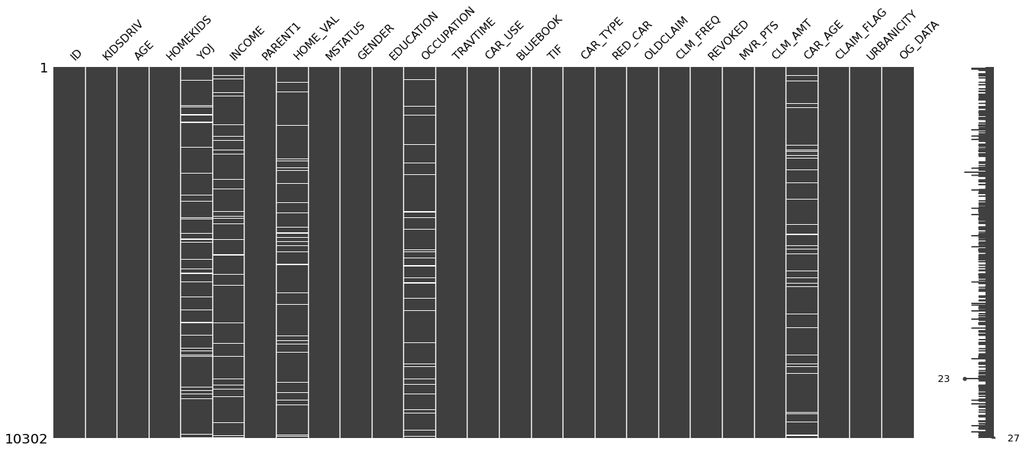

```
AGE
```

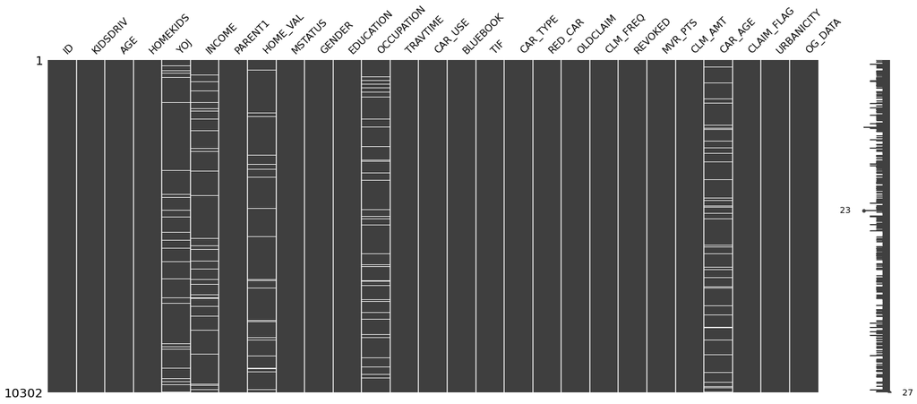

```
HOMEKIDS
```

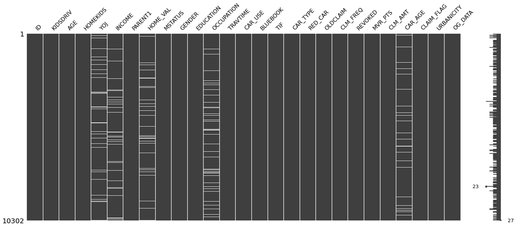

```
YOJ
```

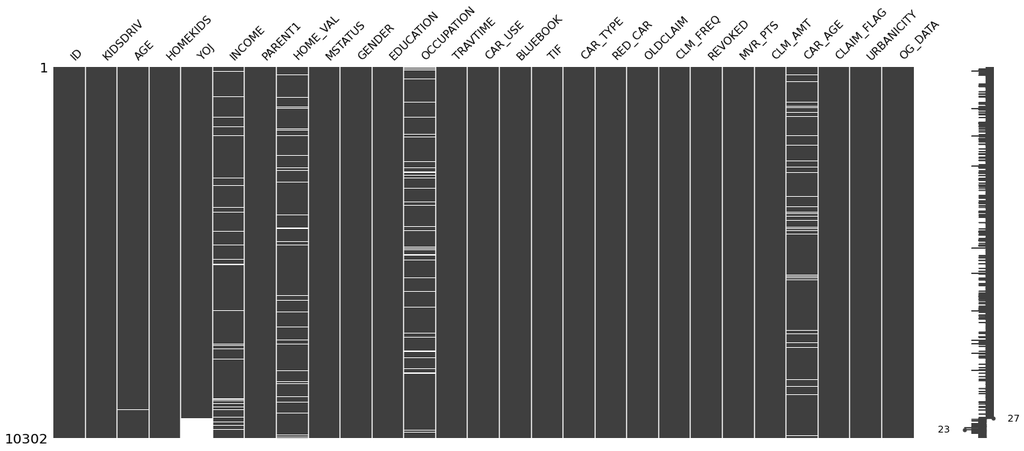

```
INCOME
```

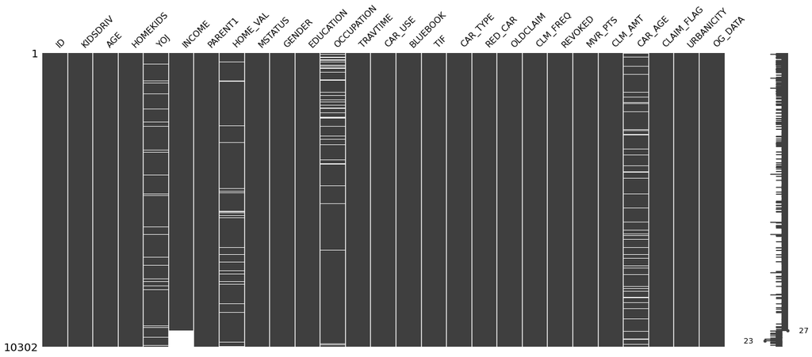

```
HOME_VAL
```

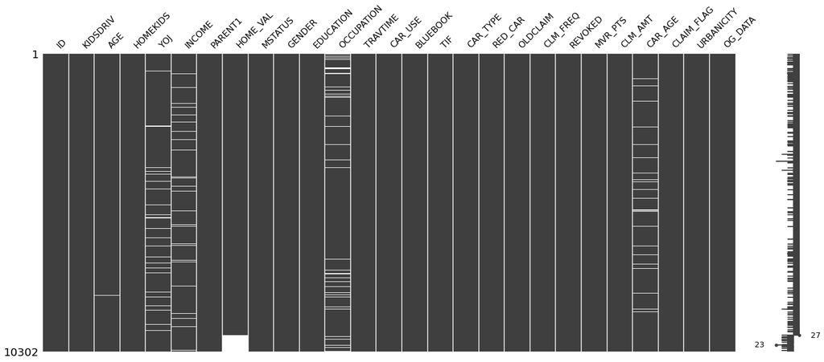

```
TRAVTIME
```

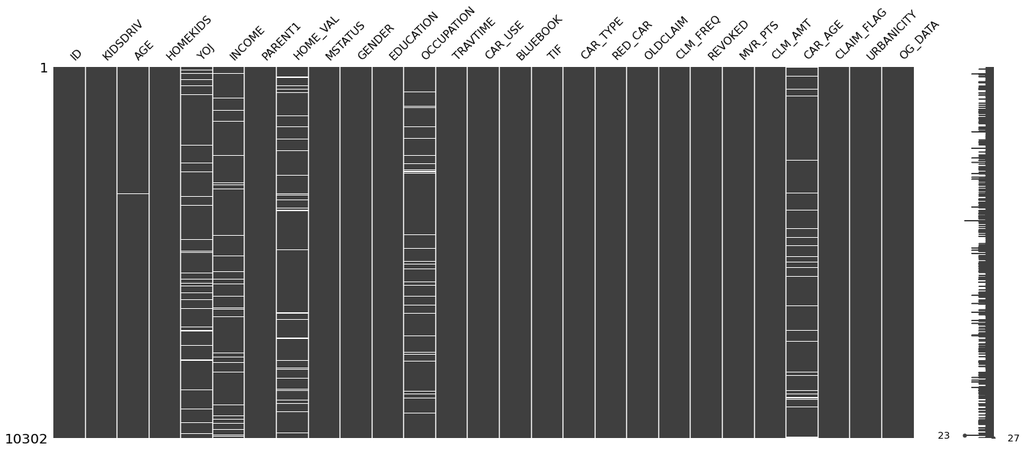

```
BLUEBOOK
```

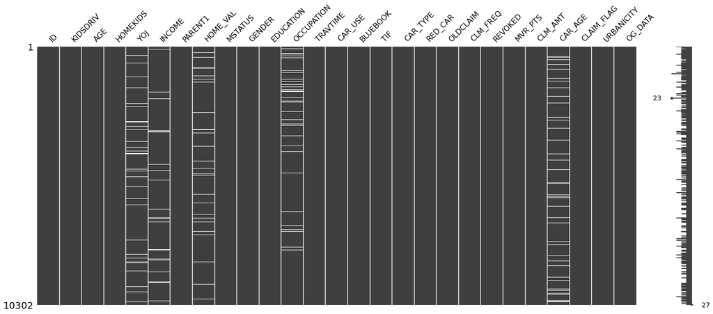

```
TIF
```

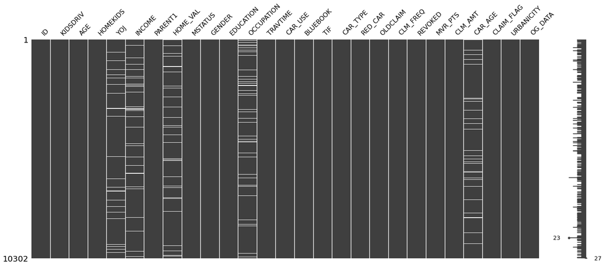

```
OLDCLAIM
```

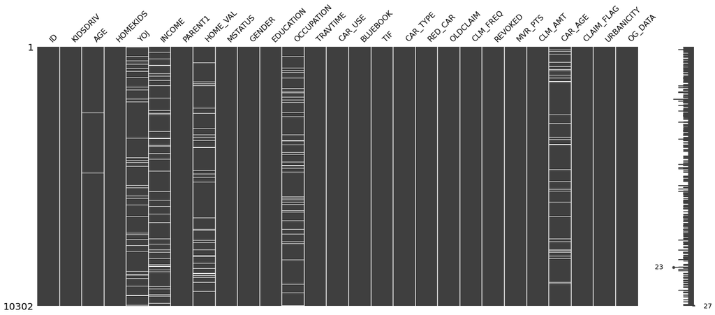

```
CLM_FREQ
```

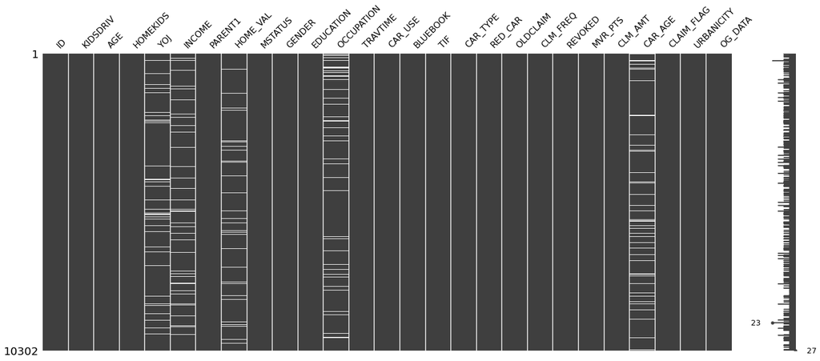

```
MVR_PTS
```

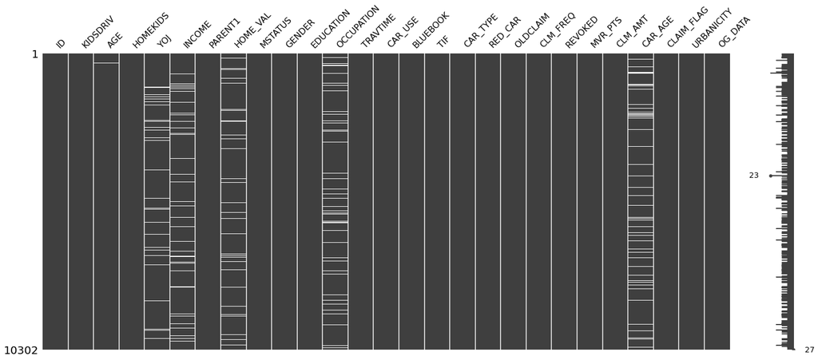

```
CLM_AMT
```

[3 more figures not shown]

```python
for column in numeric_cols:
    print(column)
    msno.matrix(df.sort_values(by=column, ascending=False))
    plt.show()
```

Powyższe wykresy sugerują, że braki dla poszeczególnych zmiennych nie zależą od poziomu wartości pozostałych zmiennych (ilościowych) za wyjątkiem zmiennej OCCUPATION, gdzie braki występują częściej w przypadku wysokich wartości dochodu i pojazdu oraz najstarszych samochodów.

Poniżej zweryfikowano, czy moze istnieć zależność pomiędzy wariantami zmiennych jakościowych a liczbą braków dla poszczególnych zmiennych.

```python
for c in [i for i in df.columns if str(df[i].dtype) == 'category']:
    print(c)
    for v in df[c].unique():
        print('= ', v)
        sliced_df = df[['AGE', 'YOJ', 'INCOME', 'HOME_VAL', 'OCCUPATION', 'CAR_AGE']][df[c] == v]
        sliced_df_nans = sliced_df.isna().sum()
        sliced_df_counts = sliced_df.count()
        sliced_df_coef = round(sliced_df_nans / sliced_df_counts, 3) * 100
        result_df = pd.concat([sliced_df_nans, sliced_df_counts, sliced_df_coef], axis=1)
        result_df.columns = ['missing rows', 'all rows', '% of missing']
        print(result_df, '\n')
```

```
GENDER
=  M
            missing rows  all rows  % of missing
AGE                    2      4755           0.0
YOJ                  243      4514           5.4
INCOME               255      4502           5.7
HOME_VAL             270      4487           6.0
OCCUPATION           527      4230          12.5
CAR_AGE              303      4454           6.8

=  F
            missing rows  all rows  % of missing
AGE                    5      5540           0.1
YOJ                  305      5240           5.8
INCOME               315      5230           6.0
HOME_VAL             305      5240           5.8
OCCUPATION           138      5407           2.6
CAR_AGE              336      5209           6.5

EDUCATION
=  PhD
            missing rows  all rows  % of missing
AGE                    0       934           0.0
YOJ                   45       889           5.1
INCOME                54       880           6.1
HOME_VAL              50       884           5.7
OCCUPATION           241       693          34.8
CAR_AGE               70       864           8.1

=  High School
            missing rows  all rows  % of missing
AGE                    2      2950           0.1
YOJ                  130      2822           4.6
INCOME               161      2791           5.8
HOME_VAL             161      2791           5.8
OCCUPATION             0      2952           0.0
CAR_AGE              171      2781           6.1

=  Bachelors
            missing rows  all rows  % of missing
```

[output cut: 184 more lines]

```
AGE                    6      8224           0.1
YOJ                  431      7799           5.5
INCOME               436      7794           5.6
HOME_VAL             469      7761           6.0
OCCUPATION           636      7594           8.4
CAR_AGE              513      7717           6.6

=  Highly Rural/ Rural
            missing rows  all rows  % of missing
AGE                    1      2071           0.0
YOJ                  117      1955           6.0
INCOME               134      1938           6.9
HOME_VAL             106      1966           5.4
OCCUPATION            29      2043           1.4
CAR_AGE              126      1946           6.5
```

Na podstawie powyższych wyników stwierdzono, że braki danych zmiennej OCCUPATION są powiązane również z wykształceniem (EDUCATION), sposobem użytkowania pojazdu (CAR_USE) oraz rodzajem pojazdu (CAR_TYPE). Braki występują częściej w przypadku osób z wyższym wykształceniem, przy komercynym użytkowaniu pojazdu oraz pojazdów typu Panel Truck/Van. Braki wartości pozostałych zmiennych nie wykazują wyraźnej zależności od innych zmiennych. Stwierdzono tym samym, że braki w zmiennej OCCUPATION są typu MAR, natomiast dla pozostałych zmiennych - MCAR, bowiem nie ma wyraźnych przesłanek do stwierdzenia nielosowego występowania braków (MNAR). Jedynie w przypadku zmiennej AGE, jak wykazano już wcześniej, braki nie są losowe, jako że zależą od wartości daty urodzenia, jednak tę uznano za błędną w przypadku brakujących wartości zmiennej AGE.

Poniżej zweryfikowano zależności w występowaniu braków danych pomiędzy poszczególnymi zmiennymi zawierającymi braki.

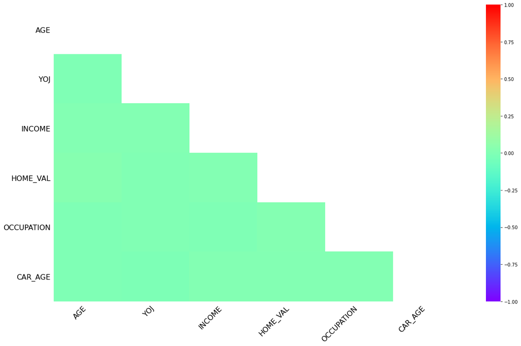

```python
msno.heatmap(df, cmap='rainbow')
plt.show()
```

Mapa ciepła wyraźnie pokazuje brak korelacji pomiędzy zmiennymi w kontekście występowania braków danych.

**Imputacja brakujących danych zmiennych ilosciowych metodą KNN**

```python
from sklearn.impute import KNNImputer
stare_df = df
imputer = KNNImputer()


liczbowe = pd.DataFrame()
for column in df.columns:
    if df[column].dtypes == 'float64' or df[column].dtypes == 'int64' or df[column].dtypes == 'float32' or df[column].dtypes == 'int32':
        copy = df[column].copy()
        liczbowe[column] = copy



imputed = pd.DataFrame(imputer.fit_transform(liczbowe),columns = liczbowe.columns)

for column in imputed.columns:
    df[column] = imputed[column]

df.isna().sum()
```

```
ID              0
KIDSDRIV        0
AGE             0
HOMEKIDS        0
YOJ             0
INCOME          0
PARENT1         0
HOME_VAL        0
MSTATUS         0
GENDER          0
EDUCATION       0
OCCUPATION    665
TRAVTIME        0
CAR_USE         0
BLUEBOOK        0
TIF             0
CAR_TYPE        0
RED_CAR         0
OLDCLAIM        0
CLM_FREQ        0
REVOKED         0
MVR_PTS         0
CLM_AMT         0
CAR_AGE         0
CLAIM_FLAG      0
URBANICITY      0
OG_DATA         0
dtype: int64
```

Powyżej dokonano imputacji braków danych zmiennych ilościowych wykorzystując metodę KNN.

**Korelacje pomiędzy zmiennymi zawierającymi braki a resztą zmiennych przed i po imputacji**

Stan przed imputacją:

```python
numeric_cols_old = []
for c in stare_df.columns[1:]:
    if str(stare_df.loc[:, c].dtype) not in ['category', 'bool']:
        numeric_cols_old.append(c)

stare_df['INCOME'].astype('float64')

korelacja_stara = pd.DataFrame()
columns=['INCOME','AGE','CAR_AGE','YOJ','OCCUPATION','HOME_VAL']
for column in columns:
    korelacja_stara[column] = stare_df[column]

correl = pd.DataFrame()
for column in korelacja_stara.drop(columns='OCCUPATION').columns:
    correl[column] = stare_df[numeric_cols_old].corr()[column]
correl
```

|  | INCOME | AGE | CAR_AGE | YOJ | HOME_VAL |
| --- | --- | --- | --- | --- | --- |
| KIDSDRIV | -0.043217 | -0.078427 | -0.059674 | 0.042971 | -0.015447 |
| AGE | 0.186202 | 1.000000 | 0.178648 | 0.140878 | 0.209600 |
| HOMEKIDS | -0.160230 | -0.447787 | -0.159103 | 0.077707 | -0.107483 |
| YOJ | 0.293899 | 0.140878 | 0.064738 | 1.000000 | 0.272198 |
| INCOME | 1.000000 | 0.186202 | 0.417340 | 0.293899 | 0.578943 |
| HOME_VAL | 0.578943 | 0.209600 | 0.223286 | 0.272198 | 1.000000 |
| TRAVTIME | -0.051853 | -0.001569 | -0.033209 | -0.017152 | -0.035139 |
| BLUEBOOK | 0.429095 | 0.166290 | 0.194393 | 0.148086 | 0.261962 |
| TIF | 0.002361 | -0.001890 | 0.007863 | 0.023921 | 0.006768 |
| OLDCLAIM | -0.039347 | -0.033378 | -0.018800 | -0.005077 | -0.059803 |
| CLM_FREQ | -0.049220 | -0.037641 | -0.018700 | -0.023535 | -0.093854 |
| MVR_PTS | -0.063495 | -0.075732 | -0.033940 | -0.041593 | -0.092460 |
| CLM_AMT | -0.057686 | -0.049034 | -0.066071 | -0.026799 | -0.091987 |
| CAR_AGE | 0.417340 | 0.178648 | 1.000000 | 0.064738 | 0.223286 |

Stan po imputacji:

```python
numeric_cols = []
for c in df.columns[1:]:
    if str(df.loc[:, c].dtype) not in ['category', 'bool']:
        numeric_cols.append(c)
korelacja = pd.DataFrame()
columns=['INCOME','AGE','CAR_AGE','YOJ','OCCUPATION','HOME_VAL']
for column in columns:
    korelacja[column] = df[column]
correll = pd.DataFrame()

for column in korelacja.drop(columns='OCCUPATION').columns:
    correll[column] = df[numeric_cols].drop(columns='OG_DATA').corr()[column]
correll
```

|  | INCOME | AGE | CAR_AGE | YOJ | HOME_VAL |
| --- | --- | --- | --- | --- | --- |
| KIDSDRIV | -0.043925 | -0.078427 | -0.056548 | 0.040055 | -0.015247 |
| AGE | 0.180820 | 1.000000 | 0.171841 | 0.134588 | 0.203764 |
| HOMEKIDS | -0.155729 | -0.447787 | -0.151492 | 0.075182 | -0.102659 |
| YOJ | 0.278395 | 0.134588 | 0.062606 | 1.000000 | 0.257936 |
| INCOME | 1.000000 | 0.180820 | 0.391636 | 0.278395 | 0.546175 |
| HOME_VAL | 0.546175 | 0.203764 | 0.210879 | 0.257936 | 1.000000 |
| TRAVTIME | -0.051788 | -0.001569 | -0.031090 | -0.016072 | -0.034641 |
| BLUEBOOK | 0.416794 | 0.166290 | 0.185740 | 0.143172 | 0.251832 |
| TIF | 0.002056 | -0.001890 | 0.008990 | 0.023353 | 0.007454 |
| OLDCLAIM | -0.038002 | -0.033378 | -0.018988 | -0.005000 | -0.060266 |
| CLM_FREQ | -0.047012 | -0.037641 | -0.018431 | -0.023209 | -0.091578 |
| MVR_PTS | -0.059894 | -0.075732 | -0.030328 | -0.038173 | -0.086955 |
| CLM_AMT | -0.054271 | -0.049034 | -0.064305 | -0.026566 | -0.085804 |
| CAR_AGE | 0.391636 | 0.171841 | 1.000000 | 0.062606 | 0.210879 |

Na podstawie powyższych wyników można stwierdzić, że korelacje nie zmieniły się znacząco po imputacji.

**Statystyki opisowe przed imputacjami**

```python
korelacja_stara.describe()
```

|  | INCOME | AGE | CAR_AGE | YOJ | HOME_VAL |
| --- | --- | --- | --- | --- | --- |
| count | 9732.000000 | 10295.000000 | 9663.000000 | 9754.000000 | 9727.000000 |
| mean | 61572.136719 | 44.837397 | 8.298768 | 10.474062 | 154522.828125 |
| std | 47457.460938 | 8.606445 | 5.713548 | 4.108943 | 129186.617188 |
| min | 0.000000 | 16.000000 | 0.000000 | 0.000000 | 0.000000 |
| 25% | 27584.000000 | 39.000000 | 1.000000 | 9.000000 | 0.000000 |
| 50% | 53529.000000 | 45.000000 | 8.000000 | 11.000000 | 160661.000000 |
| 75% | 86166.000000 | 51.000000 | 12.000000 | 13.000000 | 238256.000000 |
| max | 367030.000000 | 81.000000 | 28.000000 | 23.000000 | 885282.000000 |

##### Statystyki opisowe po imputacjach

```python
korelacja.describe()
```

|  | INCOME | AGE | CAR_AGE | YOJ | HOME_VAL |
| --- | --- | --- | --- | --- | --- |
| count | 10295.000000 | 10295.000000 | 10295.000000 | 10295.000000 | 10295.000000 |
| mean | 61405.269840 | 44.837397 | 8.291559 | 10.470753 | 154521.636309 |
| std | 46442.957737 | 8.606445 | 5.577794 | 4.023806 | 126392.044882 |
| min | 0.000000 | 16.000000 | 0.000000 | 0.000000 | 0.000000 |
| 25% | 28722.000000 | 39.000000 | 3.000000 | 9.000000 | 0.000000 |
| 50% | 53739.000000 | 45.000000 | 8.000000 | 11.000000 | 159782.000000 |
| 75% | 84621.500000 | 51.000000 | 12.000000 | 13.000000 | 234997.000000 |
| max | 367030.000000 | 81.000000 | 28.000000 | 23.000000 | 885282.000000 |

Na podstawie powyższych statystyk opisowych stwierdzono, że nie zmieniły się one znacząco po imputacji. Nieznacznie zmniejszyły się jedynie odchylenia standardowe zmiennych.

**Rozkłady zmiennych przed i po imputacji**

AGE przed imputacjami

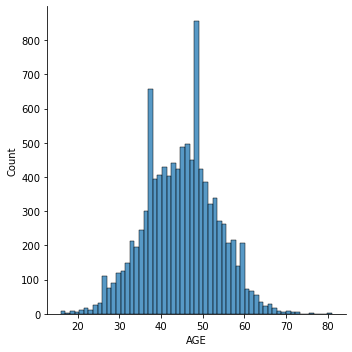

```python
sns.displot(stare_df, x="AGE")
```

AGE po imputacjach

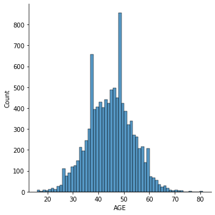

```python
sns.displot(df, x="AGE")
```

YOJ przed imputacjami

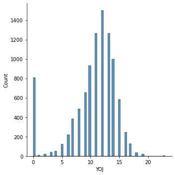

```python
sns.displot(stare_df, x="YOJ")
```

YOJ po imputacjach

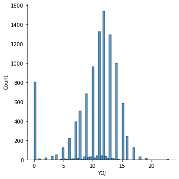

```python
sns.displot(df, x="YOJ")
```

INCOME przed imputacjami

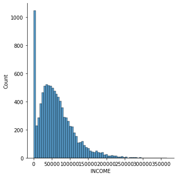

```python
sns.displot(stare_df, x="INCOME")
```

INCOME po imputacjach

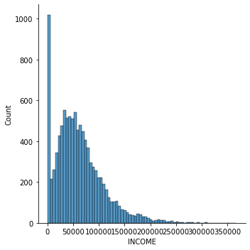

```python
sns.displot(df, x="INCOME")
```

HOME_VAL przed imputacjami

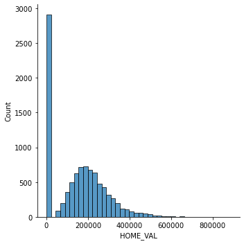

```python
sns.displot(stare_df, x="HOME_VAL")
```

HOME_VAL po imputacjach

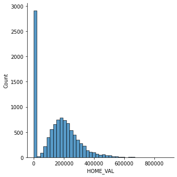

```python
sns.displot(df, x="HOME_VAL")
```

CAR_AGE przed imputacjami

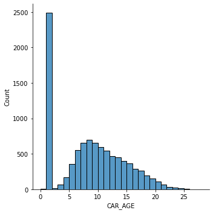

```python
sns.displot(stare_df, x="CAR_AGE")
```

CAR_AGE po imputacjach

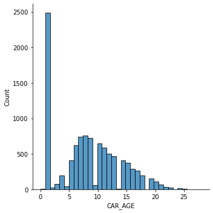

```python
sns.displot(df, x="CAR_AGE")
```

Powyższe wykresy przedstawiono w celu wizualnej weryfikacji wpływu imputacji na rozkłady zmiennych. Imputacja nie wpłynęła znacząco na rozkłady zmiennych. Różnica rozkładów zmiennej CAR_AGE wynika z pojawienia się wartości nie będących liczbami całkowitymi, co nie stanowi problemu w kontekście dalszej analizy.

### Zawód

Najpierw sprawdzono, jakie unikalne wartości przyjmuje zmienna OCCUPATION:

```python
df['OCCUPATION'].unique()
```

```
['Professional', 'Blue Collar', 'Manager', 'Clerical', 'Doctor', 'Lawyer', NaN, 'Home Maker', 'Student']
Categories (8, object): ['Blue Collar', 'Clerical', 'Doctor', 'Home Maker', 'Lawyer', 'Manager', 'Professional', 'Student']
```

Następnie utworzono mniejsze zestawy danych dla każdej unikalnej wartości zmiennej OCCUPATION:

```python
zapasowy_df = pd.DataFrame.from_dict(df)

professional = zapasowy_df.loc[df['OCCUPATION']=='Professional']
blue_collar = zapasowy_df.loc[df['OCCUPATION']=='Blue Collar']
manager = zapasowy_df.loc[df['OCCUPATION']=='Manager']
clerical = zapasowy_df.loc[df['OCCUPATION']=='Clerical']
doctor = zapasowy_df.loc[df['OCCUPATION']=='Doctor']
lawyer = zapasowy_df.loc[df['OCCUPATION']=='Lawyer']
home_maker = zapasowy_df.loc[df['OCCUPATION']=='Home Maker']
student = zapasowy_df.loc[df['OCCUPATION']=='Student']
nan = zapasowy_df.loc[df['OCCUPATION'].isnull()]
```

Poniżej wyliczono średni dochód dla każdego z zawodów:

```python
mean_professional = np.mean(professional["INCOME"])
mean_blue_collar = np.mean(blue_collar["INCOME"])
mean_manager = np.mean(manager["INCOME"])
mean_clerical = np.mean(clerical["INCOME"])
mean_doctor = np.mean(doctor["INCOME"])
mean_lawyer = np.mean(lawyer["INCOME"])
mean_home_maker = np.mean(home_maker["INCOME"])
mean_student = np.mean(student["INCOME"])
```

Następnie zdefiniowano funkcję, która ma znaleźć najbardziej zbliżoną wartość spośród listy średnich dochodów dla wartości wprowadzonej. To wszystko po to, aby dopasować zawód do wierszy, w których zawód jest wartością brakującą, na podstawie zarobków w danym wierszu.

```python
def closest_value(list, value):
    arr = np.asarray(list)
    i = (np.abs(arr - value)).argmin()
    return arr[i]
```

```python
#zbiór średnich zarobków w danym zawodzie
means = [mean_professional, mean_blue_collar, mean_manager,
         mean_clerical, mean_doctor, mean_lawyer, mean_home_maker, mean_student]
```

**Porównanie średnich zarobków w poszczególnych zawodach**

```python
srednie = pd.DataFrame()

srednie['MEAN'] = means
srednie['OCCUPATION'] = ['Professional', 'Blue Collar', 'Manager', 'Clerical', 'Doctor', 'Lawyer', 'Home Maker', 'Student']
srednie.sort_values(by='MEAN', ascending=False)
```

|  | MEAN | OCCUPATION |
| --- | --- | --- |
| 4 | 125102.618069 | Doctor |
| 5 | 87116.818817 | Lawyer |
| 2 | 86741.333652 | Manager |
| 0 | 75174.745313 | Professional |
| 1 | 58709.599563 | Blue Collar |
| 3 | 34992.050756 | Clerical |
| 6 | 15097.047325 | Home Maker |
| 7 | 9808.183259 | Student |

Średnie zarobki różnią się pomiędzy poszczególnymi zawodami i są zbliżone do siebie najbardziej w przypadku zawodu prawnika i menadżera.

**Rozkład zarobków w poszczególnych zawodach**

##### Doctor

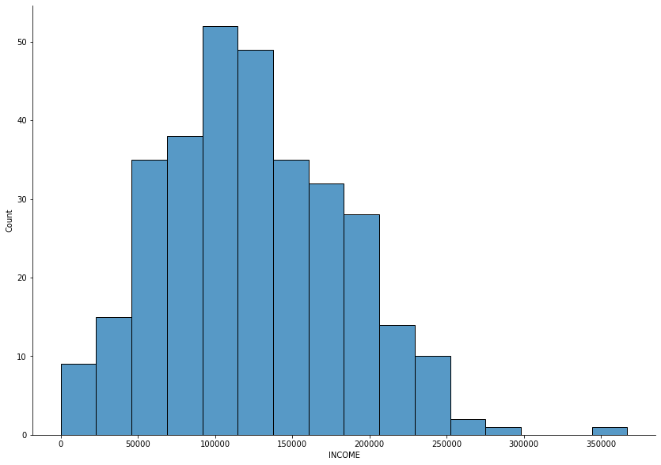

```python
sns.displot(doctor, x="INCOME", height=8.27, aspect=11.7/8.27)
```

##### Lawyer

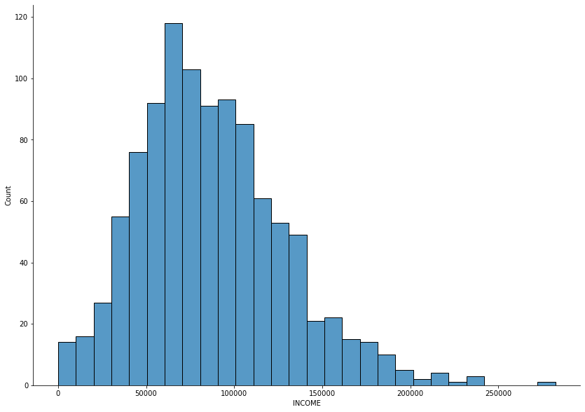

```python
sns.displot(lawyer, x="INCOME", height=8.27, aspect=11.7/8.27)
```

##### Manager

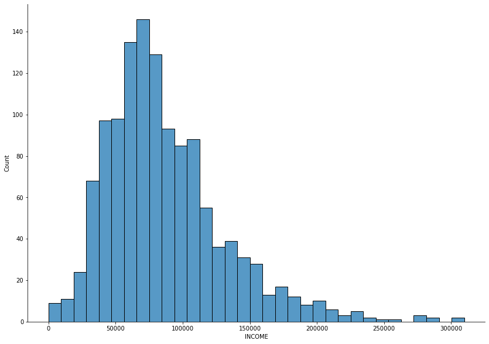

```python
sns.displot(manager, x="INCOME", height=8.27, aspect=11.7/8.27)
```

##### Professional

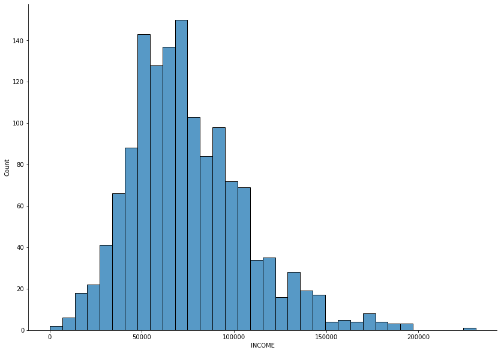

```python
sns.displot(professional, x="INCOME", height=8.27, aspect=11.7/8.27)
```

##### Blue Collar

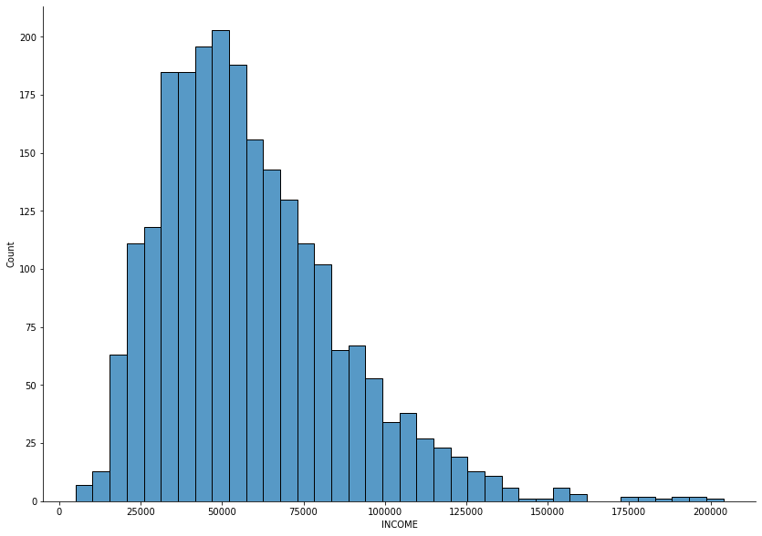

```python
sns.displot(blue_collar, x="INCOME", height=8.27, aspect=11.7/8.27)
```